# Spreadsheets

## Setup

```r
library("tidyverse")
library("knitr")
library("readxl")
library("here")
library("janitor")
```

## Sticker Wealth

We’re going to read in some messy data from an Excel file that accompanies a journal article about how children’s altruistic behavior is shaped by their “wealth” in terms of the number of stickers they have: [Being Sticker Rich: Numerical Context Influences Children’s Sharing Behavior](https://journals.plos.org/plosone/article?id=10.1371/journal.pone.0138928). The data are [archived in a data repository](https://dataverse.harvard.edu/dataset.xhtml?persistentId=doi:10.7910/DVN/LHAQ5W), but they can also be downloaded from the course website.

### Problem 1: First read

As a first attempt, let’s just read in the file using `read_excel()` with no other options provided.

Set your path here:

```r
stickers_path <- here("assignments/week-09/data/PosidFazioCordes_StickerRich_Excel-Dataverse.xlsx")
```

Then read the spreadsheet:

Let’s look at that mess.

```r
kable(head(stickers))
```

| Subject Number | Condition | Number Stickers | Number Envelopes | Gender | Age_months | Age_years | Age_groups | Subject’s Envelope | Left Envelope | Right Envelope | absolute number of stickers given (Conditions 1 or 3: Out of 12; Conditions 2 or 4: Out of 30) | Percent Given (Out of 100 percent) | Give or not | LargerEnvelope_abs | LargeEnvelope_percent | SmallerEnvelope_abs | SmallEnvelope_percent |
| --- | --- | --- | --- | --- | --- | --- | --- | --- | --- | --- | --- | --- | --- | --- | --- | --- | --- |
| [Included Sample Only] | 1=12:1; 2=12:2, 3=30:1, 4=30:2 | 1=12; 2=30 | 1=1 recipient; 2=2 recipients | 1=female; 2=male | NA | NA | 1=3-4yrs; 2=5-6yrs; 3=7-8yrs; 4=9-11yrs | How many stickers did the child keep for themselves (Raw number) | 1 recipient conditions: How many stickers the subject put in the recipient’s envelope; 2 recipient conditions: How many stickers the subject put in the recipient’s envelope to their left. | 1 recipient conditions: N/A; 2 recipient conditions: The number of stickers the subject put in the recipient’s envelope to their right. | Regardless of condition, the number of stickers the participant placed in the recipient(s) envelope(s); Raw number | Regardless of condition, the proportion of stickers the participant placed in the recipient(s) envelope(s) | 1=Donated 1 or more stickers to the recipient(s); 0=Did not donate any stickers, kept all stickers for themsleves. | Raw number of stickers (out of 30: Condition 2 or 4 only) placed in one of the two recipients’ envelopes; the larger of the two values. | Proportion of stickers (out of 100%; Condition 2 or 4 only) placed in one of the two recipients’ envelopes; the larger of the two values. | Raw number of stickers (out of 30: Condition 2 or 4 only) placed in one of the two recipients’ envelopes; the smaller of the two values. | Proportion of stickers (out of 100%; Condition 2 or 4 only) placed in one of the two recipients’ envelopes; the smaller of the two values. |
| 1 | 1 | 1 | 1 | 1 | 36 | 3 | 1 | 7 | 5 | NA | 5 | 0.42 | 1 | NA | NA | NA | NA |
| 2 | 1 | 1 | 1 | 2 | 36 | 3 | 1 | 12 | 0 | NA | 0 | 0 | 0 | NA | NA | NA | NA |
| 3 | 1 | 1 | 1 | 2 | 36 | 3 | 1 | 4 | 8 | NA | 8 | 0.67 | 1 | NA | NA | NA | NA |
| 4 | 1 | 1 | 1 | 1 | 36 | 3 | 1 | 7 | 5 | NA | 5 | 0.42 | 1 | NA | NA | NA | NA |
| 5 | 1 | 1 | 1 | 2 | 36 | 3 | 1 | 12 | 0 | NA | 0 | 0 | 0 | NA | NA | NA | NA |

That second row of data is wonky, and we can just get rid of it. There’s a nice `dplyr` function called `slice()` for choosing rows based on their position in the table. Here’s a demonstration:

```r
# Get row 2 only
slice(stickers, 2)

# Get rows 1 to 3
slice(stickers, 1:3)

# Get the last row only with the function n(), which is the number of rows in the table
slice(stickers, n())

# Get rows 2 to last row
slice(stickers, 2:n())

# Another way of writing the same thing is with negative indices (for rows to to remove)
slice(stickers, -1)
```

Another issue is that some of the column names have completely ridiculous names like `absolute number of stickers given (Conditions 1 or 3: Out of 12; Conditions 2 or 4: Out of 30)`.

```r
names(stickers)
```

```
 [1] "Subject Number"
 [2] "Condition"
 [3] "Number Stickers"
 [4] "Number Envelopes"
 [5] "Gender"
 [6] "Age_months"
 [7] "Age_years"
 [8] "Age_groups"
 [9] "Subject's Envelope"
[10] "Left Envelope"
[11] "Right Envelope"
[12] "absolute number of stickers given (Conditions 1 or 3: Out of 12; Conditions 2 or 4: Out of 30)"
[13] "Percent Given (Out of 100 percent)"
[14] "Give or not"
[15] "LargerEnvelope_abs"
[16] "LargeEnvelope_percent"
[17] "SmallerEnvelope_abs"
[18] "SmallEnvelope_percent"
```

We can rename single columns with the `dplyr` function `rename()`. Here’s a basic example of how you use this function:

```r
rename(your_data, new_col_name = old_col_name)
```

Note the normal variable names can be bare (unquoted), but for our name that is full of spaces and punctuation we’ll need to use quotes around the old name.

If we enjoyed wasting time, we could fix all the columns by manually renaming each column. Instead, let’s use the R package `janitor`, which provides a handy function `clean_names()` for making nice names using a variety of rules. By default, it makes names using [snake_case](https://en.wikipedia.org/wiki/Snake_case), but you can find all the other options in the [documentation](https://rdrr.io/cran/snakecase/man/to_any_case.html), including such delightful naming rules as “big_camel” (NamesLikeThis) and “screaming_snake” (NAMES_LIKE_THIS).

```r
clean_stickers <- clean_names(stickers)
names(clean_stickers)
```

```
 [1] "subject_number"
 [2] "condition"
 [3] "number_stickers"
 [4] "number_envelopes"
 [5] "gender"
 [6] "age_months"
 [7] "age_years"
 [8] "age_groups"
 [9] "subjects_envelope"
[10] "left_envelope"
[11] "right_envelope"
[12] "absolute_number_of_stickers_given_conditions_1_or_3_out_of_12_conditions_2_or_4_out_of_30"
[13] "percent_given_out_of_100_percent"
[14] "give_or_not"
[15] "larger_envelope_abs"
[16] "large_envelope_percent"
[17] "smaller_envelope_abs"
[18] "small_envelope_percent"
```

### Problem 2: Final read

Read in the stickers data in one fell swoop using piped functions. Your chain should be 5 lines long:

1. Start with path to the data
2. Call read_excel
3. Slice out the bad row
4. Rename the long column
5. Clean the names using janitor

## Messy Archeological Artifacts

In this activity we’re going to import data from a messy spreadsheet of mass measurements on archeological artifacts including lithics, ceramics, and molluscs. I found the data in a public respository for an [Archeological Data Analysis Workshop](https://github.com/benmarwick/SAA_R_workshop_2017) by MAtthew Harris and Ben Marwick.

Go ahead and open the file `messy_ktc_data.xlsx`. Look upon the single worksheet with tables nested within tables and despair. This file violates practically every guideline in Broman and Woo’s [“Data organization in spreadsheets”](https://kbroman.org/dataorg/).

We have three goals here:

1. Read in the subtable labeled “Ceramic data” and put it in an object called `ceramic`.
2. Read in the subtable labeled “lithic data” and put it in an object called `lithic`.
3. Read in all the mollusc data organized into 17 (?!?!!) subtables and put it all together in an object called `mollusc`.

Set your path here:

```r
artifacts_path <- here("assignments/week-09/data/messy_ktc_data.xlsx")
```

### Problem 3: Reading in two easy sub-tables

The, for each sub-table (ceramic and lithic), provide the cell range to the `read_excel()` function.

First ceramic:

```
Rows: 101
Columns: 9
$ Trench   <chr> "A", "A", "A", "A", "A", "A", "A", "A", "A", "A", "A", "A", "…
$ Square   <chr> "SW1", "SW1", "SW1", "SW1", "SW1", "SW1", "SW1", "SW1", "SW1"…
$ EU       <dbl> 1, 1, 1, 1, 1, 1, 1, 1, 1, 2, 2, 2, 2, 2, 2, 2, 2, 2, 2, 2, 2…
$ Context  <chr> "1", "1", "1", "1", "1", "1", "1", "1", "1", "1", "1", "1", "…
$ Unit     <dbl> 1, 1, 1, 1, 1, 1, 1, 1, 1, 2, 2, 2, 2, 2, 2, 2, 2, 2, 2, 2, 2…
$ Counts   <dbl> 14, 1, 1, 1, 1, 1, 1, 1, 1, 1, 51, 1, 1, 1, 1, 1, 1, 1, 1, 1,…
$ Mass     <dbl> 27.2, 5.8, 0.5, 0.0, 0.6, 0.6, 0.5, 1.0, 0.4, 5.1, 72.1, 3.5,…
$ Recorder <chr> "CC", "CC", "CC", "CC", "CC", "CC", "CC", "CC", "CC", "HVV", …
$ Date     <dttm> 2008-07-28, 2008-07-28, 2008-07-28, 2008-07-28, 2008-07-28, …
```

Then lithic:

```
Rows: 12
Columns: 10
$ Trench      <chr> "A", "A", "A", "A", "A", "A", "A", "A", "A", "A", "A", "A"
$ Square      <chr> "SW1", "SW2", "SW5", "SW6", "SW6", "SW9", "SW11", "SW14", …
$ EU          <dbl> 1, 2, 5, 6, 6, 9, 11, 14, 15, 18, 19, 20
$ Unit        <dbl> 1, 2, 9, 12, 13, 16, 17, 19, 19, 24, 27, 27
$ Lithic_Type <chr> "Flake", "Flake", "Flake", "Flake", "Flake", "Flake", "Fla…
$ Counts      <dbl> 1, 1, 20, 3, 8, 2, 2, 1, 2, 4, 2, 2
$ Mass        <dbl> 0.3, 18.4, 73.6, 6.1, 13.3, 2.7, 6.3, 0.9, 2.6, 41.0, 9.7,…
$ Recorder    <chr> "CC", "HVV", "CC", "HVV", "CC", "HVV", "HVV", "HVV", "HVV"…
$ Date        <dttm> 2008-07-28, 2008-07-28, 2008-07-28, 2008-07-28, 2008-07-28…
$ Context     <chr> "1", "1", "4", "5", "5", "6", "7U", "8", "8", "7L", "7L", …
```

### Problem 4: Reading in a more messy sub-table

Mollusc is a bit more complicated, but still not so bad. If we simply provide the cell range:

```
Rows: 199
Columns: 13
$ Trench               <chr> "A", "Trench", "A", "A", "A", "A", "A", "A", "A",…
$ Unit                 <chr> "SW2", "Unit", "SW4", "SW4", "SW4", "SW4", "SW4",…
$ Context              <chr> "2", "Context", "5", "5", "5", "5", "5", "5", "5"…
$ Taxon                <chr> "Unknown", "Taxon", "F. Viviparidae", "F. Arcidae…
$ Element              <chr> "Bivalve", "Element", "Gastropod", "Bivalve", "Ga…
$ `Mass (g)`           <chr> "0.9", "Mass (g)", "1.3", "0.8", "1.5", "16.7", "…
$ Count                <chr> "1", "Count", "1", "1", "1", "8", "8", "12", "4",…
$ `Max L/W mm`         <chr> "NA", "Max L/W mm", "NA", "NA", "NA", "NA", "NA",…
$ `Burnt/Not Burnt`    <chr> "N", "Burnt/Not Burnt", "N", "N", "N", "N", "N", …
$ `Cutmark/No Cutmark` <chr> "N", "Cutmark/No Cutmark", "N", "N", "N", "N", "N…
$ Recorder             <chr> "HVV", "Recorder", "HVV", "HVV", "HVV", "HVV", "H…
$ NOTES                <chr> NA, "NOTES", NA, NA, NA, NA, NA, NA, NA, NA, "NOT…
$ Date                 <chr> "41099", "Date", "41099", "41099", "41099", "4109…
```

Everything is treated as a text column because the column headings for each subtable are intermixed with the data values. To fix this, write a sequence of commands in which you:

1. Start with path to the data.
2. Call read_excel() on the appropriate range and use the `col_types` argument to specify the column type for each column.
3. Filter out all the rows that correspond with column headings.
4. Clean the names using `clean_names()` from the `janitor` package.

```
Rows: 183
Columns: 13
$ trench             <chr> "A", "A", "A", "A", "A", "A", "A", "A", "A", "A", "…
$ unit               <chr> "SW2", "SW4", "SW4", "SW4", "SW4", "SW4", "SW4", "S…
$ context            <chr> "2", "5", "5", "5", "5", "5", "5", "5", "5", "9", "…
$ taxon              <chr> "Unknown", "F. Viviparidae", "F. Arcidae Anadara sp…
$ element            <chr> "Bivalve", "Gastropod", "Bivalve", "Gastropod", "Ga…
$ mass_g             <dbl> 0.9, 1.3, 0.8, 1.5, 16.7, 3.2, 1.4, 3.7, 1.0, 1.3, …
$ count              <dbl> 1, 1, 1, 1, 8, 8, 12, 4, 2, 1, 1, 1, 1, 2, 1, 3, 4,…
$ max_l_w_mm         <dbl> NA, NA, NA, NA, NA, NA, NA, NA, NA, 21.16, 25.06, 2…
$ burnt_not_burnt    <chr> "N", "N", "N", "N", "N", "N", "N", "N", "N", "N", "…
$ cutmark_no_cutmark <chr> "N", "N", "N", "N", "N", "N", "N", "N", "N", "N", "…
$ recorder           <chr> "HVV", "HVV", "HVV", "HVV", "HVV", "HVV", "HVV", "H…
$ notes              <chr> NA, NA, NA, NA, NA, NA, NA, NA, NA, "F-100-0168 B-1…
$ date               <dttm> 2012-07-09, 2012-07-09, 2012-07-09, 2012-07-09, 20…
```

Finally, let’s make a histogram to visualize the mass distributions of bivalves and gastropods from our sample.

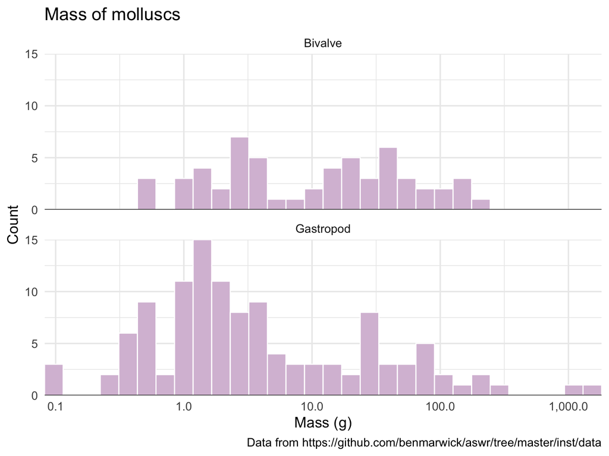